# One month as a procrastinator on Stack Overflow

Florian Privé

July 27, 2017

Hello everyone, I’m 6103040 aka F. Privé. In this post, I will give some insights about answering questions on Stack Overflow (SO) for a month. One of the reason I’ve began frenetically answering questions on Stack Overflow was to procrastinate while finishing a scientific manuscript.

## My activity on Stack Overflow

We’ll use David Robinson’s package **stackr** to get data from Stack Overflow API.

```r
# devtools::install_github("dgrtwo/stackr")
suppressMessages({
  library(stackr)
  library(tidyverse)
  library(lubridate)
})
```

### Evolution my SO reputation

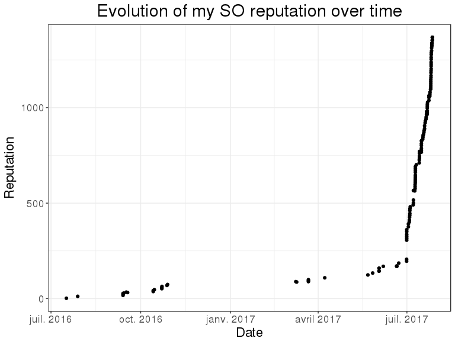

```r
myID <- "6103040"

myRep <- stack_users(myID, "reputation-history", num_pages = 10)

(p <- myRep %>%
    arrange(creation_date) %>%
    ggplot(aes(creation_date, cumsum(reputation_change))) %>%
    bigstatsr:::MY_THEME() +
    geom_point() +
    labs(x = "Date", y = "Reputation",
         title = "Evolution of my SO reputation over time"))
```

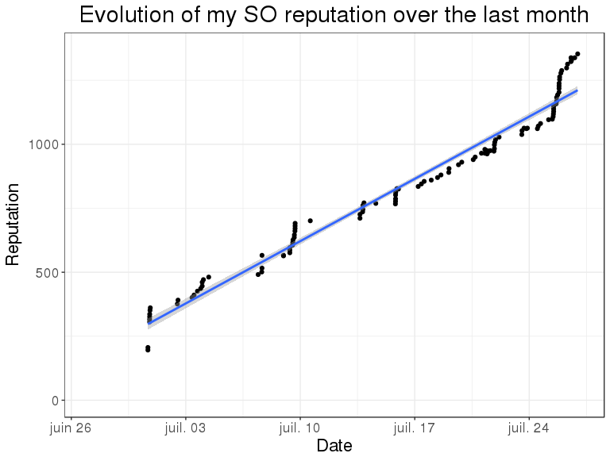

```r
p +
  xlim(as.POSIXct(c(today() - months(1), today()))) +
  geom_smooth(method = "lm") +
  ggtitle("Evolution of my SO reputation over the last month")
```

### Analyzing my answers

```r
(myAnswers <- stack_users(myID, "answers", num_pages = 10,
                          fromdate = today() - months(1)) %>%
    select(-starts_with("owner")) %>%
    arrange(desc(score)) %>%
    as_tibble())
```

```
## # A tibble: 63 x 7
##    is_accepted score  last_activity_date       creation_date answer_id
##          <lgl> <int>              <dttm>              <dttm>     <int>
##  1       FALSE     9 2017-07-17 11:07:14 2017-07-16 22:21:05  45132967
##  2       FALSE     5 2017-07-25 09:27:02 2017-07-25 09:27:02  45296612
##  3       FALSE     5 2017-07-09 08:27:24 2017-07-09 08:27:24  44993632
##  4        TRUE     4 2017-06-30 18:57:23 2017-06-30 18:56:04  44851544
##  5       FALSE     3 2017-07-09 11:15:17 2017-07-09 11:15:17  44994826
##  6        TRUE     3 2017-07-02 10:27:29 2017-07-02 10:27:29  44868837
##  7        TRUE     2 2017-07-25 19:44:33 2017-07-25 19:44:33  45310305
##  8        TRUE     2 2017-07-25 15:41:12 2017-07-25 15:41:12  45305138
##  9        TRUE     2 2017-07-23 12:55:24 2017-07-23 12:55:24  45264278
## 10        TRUE     2 2017-07-21 20:50:42 2017-07-21 20:13:12  45244205
## # ... with 53 more rows, and 2 more variables: question_id <int>,
## #   last_edit_date <dttm>
```

So it seems I’ve answered 63 questions over the past month. Interestingly, my answers with the greatest scores were not accepted. You can get a look at these using

```
sapply(c("https://stackoverflow.com/questions/45045318",
         "https://stackoverflow.com/questions/45295642",
         "https://stackoverflow.com/questions/44993400"), browseURL)
```

The first one is just translating some R code in Rcpp. The two other ones are **dplyr** questions.

```r
myAnswers %>%
  group_by(score) %>%
  summarise(
    N = n(),
    acceptance_ratio = mean(is_accepted)
  )
```

```
## # A tibble: 8 x 3
##   score     N acceptance_ratio
##   <int> <int>            <dbl>
## 1    -2     1        0.0000000
## 2     0    32        0.3125000
## 3     1    14        0.4285714
## 4     2    10        0.7000000
## 5     3     2        0.5000000
## 6     4     1        1.0000000
## 7     5     2        0.0000000
## 8     9     1        0.0000000
```

My acceptance rate is quite bad.

### Tags I’m involved in

```r
stack_users(myID, "tags", num_pages = 10) %>%
  select(name, count) %>%
  DT::datatable()
```

|  | name | count |
| --- | --- | --- |
| 1 | r | 79 |
| 2 | dplyr | 10 |
| 3 | dataframe | 6 |
| 4 | r-bigmemory | 5 |
| 5 | rcpp | 5 |
| 6 | parallel-foreach | 4 |
| 7 | rmarkdown | 4 |
| 8 | matrix | 3 |
| 9 | data.table | 3 |
| 10 | foreach | 3 |

[output cut: 69 more lines]

- I’m obviously answering only R questions
- Questions about data frames or **dplyr** are quite easy so that I’ve answered several of them
- I’m answering tags *r-bigmemory*, *rcpp*, *foreach*, *parallel-foreach* as I’m getting good at it because of the package I’ve developed (see [my previous post](https://privefl.github.io/blog/package-bigstatsr-statistics-with-matrices-on-disk-user-2017/)).

## Some insights from this experience

- **purrr** is badly received as a proxy of base R functions such as `sapply` and `lapply` (https://stackoverflow.com/questions/45101045/why-use-purrrmap-instead-of-lapply)
- People tend to use **dplyr** where base R functions are well-suited:
  - https://stackoverflow.com/questions/45244063/using-dplyr-to-replace-a-vector-of-names-with-new-names
  - https://stackoverflow.com/questions/45243363/dplyr-to-calculate-of-prevalence-of-a-variable-in-a-condition
  - https://stackoverflow.com/questions/44881723/replace-column-by-another-table
  - https://stackoverflow.com/questions/44995997/create-a-new-variable-using-dplyrmutate-and-pasting-two-existing-variables-for
  - https://stackoverflow.com/questions/45309455/mean-function-producing-same-result
- To avoid basic issues, I find very important to know base R classes and their accessors well (you just need to read [Advanced R](http://adv-r.had.co.nz/))
- The tidyverse solves lots of problems (you just need to read [R for Data Science](http://r4ds.had.co.nz/))
- Guiding to a solution is much more fun than just giving it (https://stackoverflow.com/questions/45308904).

## Conclusion and bonuses

I think it has been a good experience to answer questions on SO for a month.

I’m proud of [this algorithm written only with **dplyr**](https://stackoverflow.com/a/45302898/6103040) that automatically get you a combination of variables to form a [unique key](https://en.wikipedia.org/wiki/Unique_key) of a dataset. Also, I wanted to make a blog post about good practices for parallelization in R. I’m not sure how to do it and which format to use, but, for now, you can get [some good practices in one of my answer](https://stackoverflow.com/a/45196081/6103040). Finally, if you miss the previous infinite printing of a tibble, you can get a workaround [there](https://stackoverflow.com/a/44868837/6103040).